# Gas Tax Assignment

Daphne Virlar & Laura Ingulsrud

May 1, 2019

## **Technical Appendix**

#### **1.**

Aggregate daily demand curve for gasoline in France: $P_{Aggregate} = (-6.63*10^{-5})*Q_{Aggregate} + 22.71$

Supply curve for gasoline: $P_{Supply} = (1.87*10^{-5})*Q_{Supply}$

Environmental cost: $534,352.40

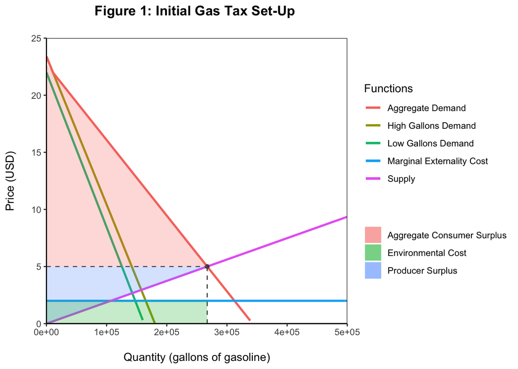

#### **3.**

Effect of gas tax on quantity of gasoline produced and sold in France: The tax decreased the amount of gasoline by 5,883.6 gallons; from 267,176.2 gallons pre-tax to 261,292.6 gallons post-tax.

Effect of gas tax on price of gasoline: The tax increased the gasoline price by $0.39; from $5 pre-tax to $5.39 post-tax.

Effect of gas tax on high income CS: The tax decreased high income CS by $54,696; from $1,303.747 pre-tax to $1,249,051 post-tax.

Effect of gas tax on low income CS: The tax increased low income CS by $47,205; from $969,635 pre-tax to $1,016,840 post-tax.

Effect of gas tax on PS: The tax decreased PS by $29,093.91; from $667,940.50 pre-tax to $638,846.59 post-tax.

Effect of gas tax on environmental cost: The tax decreased environmental cost by $11,767.10; from $534,352.40 pre-tax to $522,585.30 post-tax.

Effect of gas tax on total revenue: The tax generated a total revenue of $130,646.

#### **4.**

Effect of range of gas taxes on high income consumer surplus:

Effect of range of gas taxes on low income consumer surplus:

| USD Tax Amount | Millions USD Low Income Consumer Welfare | Millions USD High Income Consumer Welfare | Millions USD Producer Welfare |
| --- | --- | --- | --- |
| 1 | 0.578 | 1.332 | 0.611 |
| 2 | 0.619 | 1.352 | 0.556 |
| 3 | 0.653 | 1.365 | 0.503 |
| 4 | 0.679 | 1.371 | 0.453 |
| 5 | 0.699 | 1.369 | 0.406 |

#### **5.**

Effects of electric car popularity on quantity of gasoline consumed by high income consumers: Gas consumption by high income consumers is halved; the quantity decreases from 157,599.4 gallons to 78,799.72 gallons post-electric car popularity.

Effects of electric car popularity on quantity of gasoline consumed by low income consumers: Gas consumption by low income consumers is halved; the quantity decreases from 142,593.8 gallons to 71,296.9 gallons post-electric car popularity.

#### **6.**

The invention of electric cars has a bigger impact on environmental quality as it lowers the environmental cost by $220,107.70 more than a $2/gal gas tax does.